# Development of Predictive Models for the successful selling of iPads on ebay

Soledad Galli

15 August 2015

**In this section, I will show 2 of the predictive models I built to predict the selling of an iPad on ebay. In addition, I discuss the variables I introduced to increase the predictive power of the models.**

In addition to the variables provided in the dataset, I created additional variables based on the characteristics of the listings, which are generally known to be predictors for good selling on ebay. These variables were:

- noDescription: indicating if a listing has a description at all
- TotalWords: the length of the description
- goodcon: Indicates whether the description clarifies that the item is in good condition
- lowStartPrice: Shows if the item’s starting price is below U$S 240

For the remaining variables, it is not inmediately clear whether they would contribute significantly to predict if an iPad will sell: roughly the same proportion of items are sold and fail to sell.

```r
proportions
```

```
## $Bid
##
##       0   1
##   0 800 217
##   1 197 638
##
## $LowStartPrice
##
##       0   1
##   0 528 152
##   1 469 703
##
## $NoDescription
##
##       0   1
##   0 445 343
##   1 552 512
##
## $GoodCondition
##
##       0   1
##   0 948 832
##   1  49  23
##
## $Carrier
##
##              0   1
##   AT&T     115  91
##   None     563 541
##   Other      0   2
##   Sprint    17  13
##   T-Mobile  11   8
##   Unknown  212 135
##   Verizon   79  65
##
## $Product
##
##                 0   1
##   iPad 1      102 125
##   iPad 2      139 147
##   iPad 3       73  80
##   iPad 4       93  64
##   iPad Air    102  78
##   iPad Air 2  100  71
##   iPad mini   145 132
##   iPad mini 2  58  49
##   iPad mini 3  63  27
##   Unknown     122  82
```

To build the predictive models, I separated my original dataset into a training dateset containing 70% of the iPad listings, and a test dataset with 30% of the listings. I built the models on the training set and evaluated them on the test set.

Within the code file ebayPreditiveModels.R you will find all the different models I built. Here I will mention only a few as an example.

The first model, was a logistics regression model using all the variables except the text variable description

```r
logReg = glm(sold ~., data = train, family = binomial)
testPred = predict(logReg, newdata = test, type = 'response')
predictionsTable = table(test$sold, testPred > 0.5)
accuracy = (predictionsTable[1,1]+predictionsTable[2,2])/sum(predictionsTable)
predictionsTable
```

```
##
##     FALSE TRUE
##   0   241   58
##   1    62  195
```

```r
accuracy
```

```
## [1] 0.7841727
```

```r
summary(logReg)
```

```
##
## Call:
## glm(formula = sold ~ ., family = binomial, data = train)
##
## Deviance Residuals:
##     Min       1Q   Median       3Q      Max
## -2.5394  -0.7027  -0.2623   0.6290   3.5420
##
## Coefficients:
##                                     Estimate Std. Error z value Pr(>|z|)
## (Intercept)                        15.257788 464.856977   0.033 0.973816
## biddable                            1.612447   0.168303   9.581  < 2e-16
## startprice                         -0.011947   0.001320  -9.053  < 2e-16
## conditionManufacturer refurbished   1.189957   0.560995   2.121 0.033909
## conditionNew                        0.989701   0.371648   2.663 0.007745
## conditionNew other (see details)    0.882725   0.433885   2.034 0.041905
## conditionSeller refurbished         0.103226   0.427204   0.242 0.809065
## conditionUsed                       0.727938   0.258756   2.813 0.004905
## cellular1                         -13.513419 464.856421  -0.029 0.976809
## cellularUnknown                   -13.850900 464.856217  -0.030 0.976230
## carrierNone                       -13.764416 464.856450  -0.030 0.976378
## carrierOther                       12.736216 620.498160   0.021 0.983624
## carrierSprint                       0.688243   0.636560   1.081 0.279612
## carrierT-Mobile                    -0.098583   0.906088  -0.109 0.913361
## carrierUnknown                     -0.291064   0.405504  -0.718 0.472892
## carrierVerizon                      0.151992   0.353564   0.430 0.667280
## colorGold                          -0.659634   0.548106  -1.203 0.228791
## colorSpace Gray                    -0.127960   0.296846  -0.431 0.666422
## colorUnknown                       -0.027374   0.202918  -0.135 0.892691
## colorWhite                         -0.253905   0.226564  -1.121 0.262426
## storage16                          -1.317814   0.491017  -2.684 0.007278
## storage32                          -1.234444   0.501637  -2.461 0.013862
## storage64                          -0.905624   0.493996  -1.833 0.066764
## storageUnknown                     -0.725630   0.639756  -1.134 0.256698
## productlineiPad 2                   0.514202   0.291885   1.762 0.078127
## productlineiPad 3                   1.105860   0.347953   3.178 0.001482
## productlineiPad 4                   1.104740   0.361521   3.056 0.002245
## productlineiPad Air                 1.804056   0.400360   4.506 6.60e-06
## productlineiPad Air 2               2.989976   0.513256   5.826 5.69e-09
## productlineiPad mini                0.638684   0.300781   2.123 0.033718
```

[output cut: 40 more lines]

```
## productlineUnknown
## TotalWords
## lowstartprice
## nodescription
## goodcon
## ---
## Signif. codes:  0 '***' 0.001 '**' 0.01 '*' 0.05 '.' 0.1 ' ' 1
##
## (Dispersion parameter for binomial family taken to be 1)
##
##     Null deviance: 1788.9  on 1295  degrees of freedom
## Residual deviance: 1163.5  on 1259  degrees of freedom
## AIC: 1237.5
##
## Number of Fisher Scoring iterations: 13
```

This model has a modest accuracy. We observe that the variables biddable, startprice, condition, productline and storage are significant, indicating that they are good predictors in the logistic regression model, of whether an iPad will be sold. On the contrary, the color and carrier of the iPad are not good predictors of a successfull sale. The variables that I introduced (good condition, presence of description, length of the description) do not seem to contribute to enhance the predictive power of the model.

I then built a series of random forest trees to predict the sale of an iPad on ebay. Below I show the model with the highest accuracy.

```r
set.seed(2000)
ebayRF =  randomForest(sold ~., data = train)
testPred = predict(ebayRF, newdata = test, type = 'prob')[,2]
library(ROCR)
ROCRpred = prediction(testPred, test$sold)
auc = as.numeric(performance(ROCRpred, "auc")@y.values)
predictionsTable = table(test$sold, testPred > 0.5)
accuracy = (predictionsTable[1,1]+predictionsTable[2,2])/sum(predictionsTable)
accuracy
```

```
## [1] 0.8183453
```

```r
auc
```

```
## [1] 0.8760395
```

```r
ebayRF$importance
```

[output not shown]

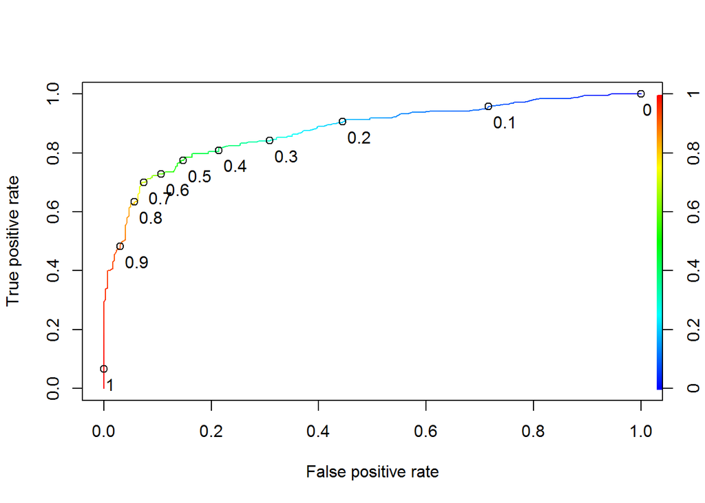

```r
ROCRperf = performance(ROCRpred, "tpr", "fpr")
plot(ROCRperf, colorize=TRUE, print.cutoffs.at=seq(0,1,by=0.1), text.adj=c(-0.2,1.7))
```

Conclusion: we identified which variables contribute significantly to predict whether an iPad will be sold on iPad. These variables were implemented in a random forest trees model for the predictions.

**This information is useful, as it allows ebay to provide better advice to their sellers on how to generate improved listings that will increase the chances of selling the iPad.**